# Demirci_Lichtenstein_Park_HW3

```python
import numpy as np
import csv
from sklearn.model_selection import KFold
from sklearn.feature_extraction.text import TfidfVectorizer
import matplotlib.pyplot as plt
from sklearn.preprocessing import LabelEncoder
from sklearn.metrics import confusion_matrix
%matplotlib notebook
```

## Define Model

### Logistic sigmoid function

Since we are dealing with a target that has a range from 0 to 1, we need to squash the outcomes into the interval $[0,1]$ by using the logistic sigmoid function, which is defined as

$$ \sigma(\mathbf{w},\mathbf{X}) = \frac{1}{1 +e^ {-\mathbf{w}\cdot \mathbf{X}}}$$

where $ \mathbf{w} $ is the weight vector and $ \mathbf{X} $ is the data.

```python
def sigmoid(w, X):
    return (1. / (1. + np.exp(-np.dot(X,w))))
```

### Loss function

We use the cros entropy loss function for logistic regression and include the regularizer term as the following

$$ Loss = \frac{1}{m}\big[- \mathbf{t}^{T}\ln(\sigma(\mathbf{w},\mathbf{X})) - (\mathbf{1} - \mathbf{t})^{T} \ln(\mathbf{1}-\sigma(\mathbf{w},\mathbf{X})\big] + \frac{\lambda}{2m}\mathbf{w}^{T}\mathbf{w} $$

```python
def loss(w, X, t, lam):
    m = X.shape[0]
    y = sigmoid(w,X)
    J = (1. / m) *(- np.dot(t.T,np.log(y)) - np.dot((1. - t.T),np.log(1. - y)))
    regularizer = (lam / (2. * m)) * np.dot(w.T, w)
    J += regularizer
    return J
```

The partial derivative of the loss function with respect to the vector $\mathbf{w}$ is

$$ \nabla_{\mathbf{w}} Loss = \frac{1}{m}[(\sigma(\mathbf{w},\mathbf{X}) - \mathbf{t})^{T}\mathbf{X}]^T + \frac{\lambda}{m}\mathbf{w} $$

```python
def partial(w, X, t, lam):
    m = X.shape[0]
    y = sigmoid(w, X)
    d = (1. / m) * np.dot((y - t).T, X).T
    reg = (lam / m) * w
    d = d + reg
    return d
```

### Learning rule

```python
def update_parameter(w, d, iteration, rate = .2, a = -.9):
    w = w - rate * (iteration ** a) * d
    return w
```

### Gradient Descent

The gradient updates w until the loss converges.

```python
#define gradient descent
def gradient_descent(w, X, t, lam, max_step = 1000, convergence = 0.00001):
    counter = 1
    L = loss(w, X, t, lam)
    L_prev = L + 10
    #update w until loss converges
    while(abs(L - L_prev) > convergence) and (counter <= max_step):
        L_prev =  L
        L = loss(w, X, t, lam)
        d = partial(w, X, t, lam)
        w = update_parameter(w, d, counter)
        counter += 1

    w_norm = np.linalg.norm(w)
    results = {"Weights": w, "Limit" : L, "W_norm": w_norm}
    return results
```

### 10-fold cross validation

```python
#find optimum lambda
def seek_lambda(X, t, stop, step_size = 1, start = 0):
    #get index lists for split
    kf = KFold(n_splits = 10)
    #find total steps within interval
    total_steps = int((stop - start) / step_size)
    lam = start

    results = {}
    for i in range(total_steps):
        loss_results = []
        w_results= []
        w= np.asarray([1 for i in range(max_features)])
        #w = np.random.random([max_features])
        #cross validate
        for train_index, test_index in kf.split(X):
            X_train, V, X_target, V_target = X[train_index, :], X[test_index, :], t[train_index], t[test_index]
            gd = gradient_descent(w, X_train, X_target, lam)
            w = gd["Weights"]
            w_n = gd["W_norm"]
            validation_loss  = loss(w, V, V_target, lam = 0)
            loss_results.append(validation_loss)
            w_results.append(w_n)
        #average the loss
        L = np.mean(loss_results)
        W = np.mean(w_results)
        results[lam] = [L,W]
        lam += step_size
    return (results)
```

Define a rule for classification.

```python
#define rule
def label_rule(prob):
    if prob>0.5:
        return 1
    else :
        return 0
```

## Fit Model

Now, we find the optimal weight vector $\mathbf{w}$ by running logistic regression on the training data.

```python
#read in data
f = open("/Users/HAD/Desktop/Last Fall/Machine Learning/HW3/train.csv", "r", errors='ignore')
raw_data = list(csv.reader(f))[1:]
print(raw_data[0:5])
```

```
[['ham', 'Hey you can pay. With salary de. Only  &lt;#&gt; .   '], ['ham', 'What happen dear. Why you silent. I am tensed   '], ['ham', 'I can do that! I want to please you both inside and outside the bedroom...   '], ['ham', 'I wonder how you got online, my love ? Had you gone to the net cafe ? Did…
```

```python
#seperate label and features
target, X = zip(*raw_data)
X =list(X)
t = np.asarray(target)
```

```python
#convert target to numeric
le =LabelEncoder() #get model
fit =le.fit(target) #fit model
t  = fit.transform(t) #transform
```

```python
X[1]
```

```
'What happen dear. Why you silent. I am tensed   '
```

```python
t[1]
```

```
0
```

### Tokenization

As the first step, we tokenize the input vector and apply tf-idf transform. Set max_features as 80, and n_gram range to (2,3) to include 2 or 3 word features. This can be optimized in further applications. However, this setting gives acceptable results given the computational requirements.

```python
# convert features to numeric
max_features = 80 #define max features allowed
```

```python
# convert features to numeric
vectorizer = TfidfVectorizer(ngram_range = (2,3), max_features = max_features, stop_words = "english")
X  = vectorizer.fit_transform(X).toarray()
X.shape
```

```
(3000, 80)
```

```python
#Sampling
#s = 1000 #define sample size
#index =np.random.randint(1,3000,s) #random sample
#slice for prototype

#X = X[index, :]
#t = t[index]
#X.shape
#t.shape
```

Since we normalize by the lenght of X (3000), lambda values are on the order of 10^3.

```python
test = seek_lambda(X, t, 20000)
```

```python
x = list(test.keys())
y = list(test.values())
losses, norm = zip(*y)
```

### Optimal lambda

We find the optimal lambda as 16265.

```python
best_lambda = losses.index(min(losses))
best_lambda
```

```
16265
```

#### Plot: Cross-entropy loss against lambda

We can visually check that the cross-entropy loss curve reaches its minumum at $\lambda = 16265$ also our assumptions (convexity etc.) seem valid.

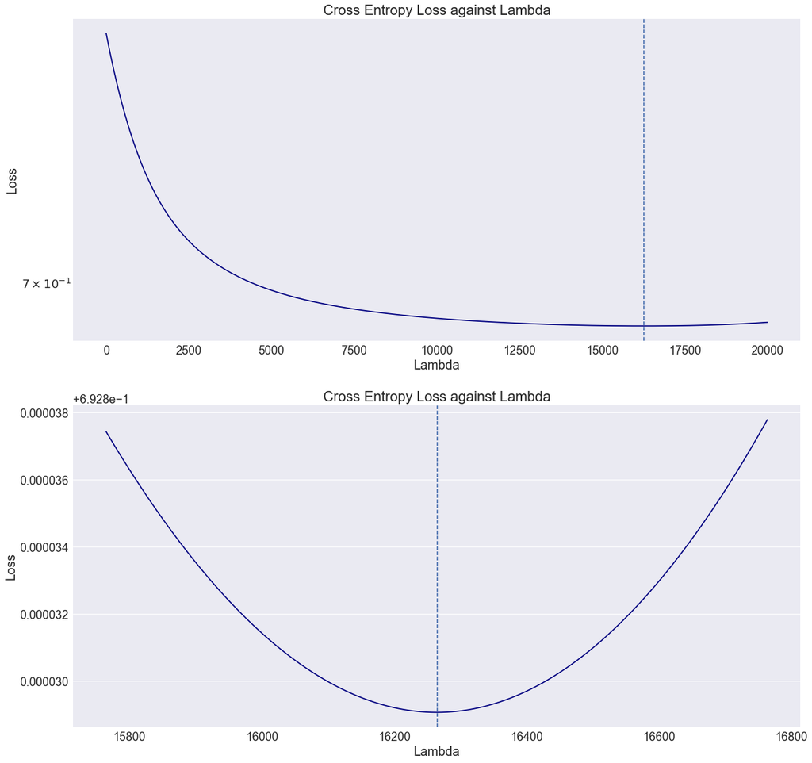

```python
%matplotlib inline
fig = plt.figure(figsize=(20,20))
ax1 = fig.add_subplot(2,1,1)
ax2 = fig.add_subplot(2,1,2)

ax1.semilogy(x[0:20000], losses[0:20000],color='navy')
ax1.tick_params(bottom='off',top='off',left='off',right='off')
ax1.spines["right"].set_visible(False)
ax1.spines["left"].set_visible(False)
ax1.spines["top"].set_visible(False)
ax1.spines["bottom"].set_visible(False)
ax1.axvline(x = best_lambda, ls = "dashed")
ax1.set(title='Cross Entropy Loss against Lambda', ylabel='Loss', xlabel = "Lambda")
ax2.plot(x[best_lambda-500:best_lambda+500], losses[best_lambda-500:best_lambda+500],color='navy')
ax2.tick_params(bottom='off',top='off',left='off',right='off')
ax2.spines["right"].set_visible(False)
ax2.spines["left"].set_visible(False)
ax2.spines["top"].set_visible(False)
ax2.spines["bottom"].set_visible(False)
ax2.axvline(x = best_lambda, ls = "dashed")
ax2.set(title='Cross Entropy Loss against Lambda', ylabel='Loss', xlabel = "Lambda")
ax1.grid(axis = "x")
ax2.grid(axis = "x")
#plt.stem(min_index,loss[min_index])
plt.show()
```

#### Plot: Weight against lambda

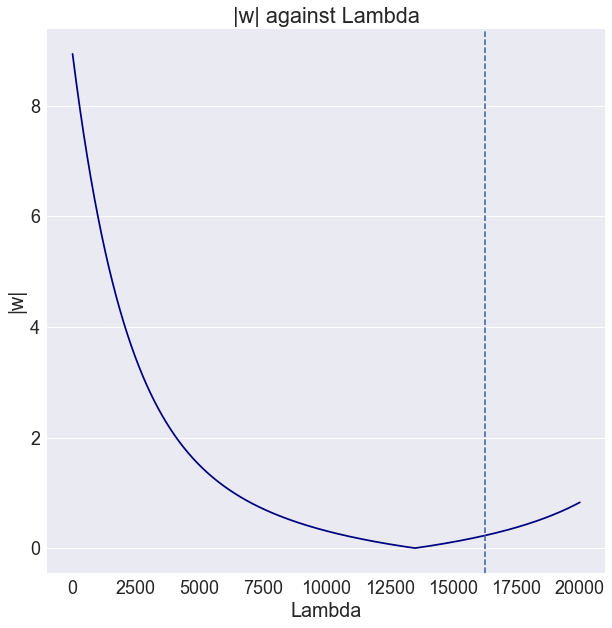

```python
%matplotlib inline
fig = plt.figure(figsize=(10,10))
ax1 = fig.add_subplot(1,1,1)

ax1.plot(x[0:20000], norm[0:20000],color='navy')
ax1.tick_params(bottom='off',top='off',left='off',right='off')
ax1.spines["right"].set_visible(False)
ax1.spines["left"].set_visible(False)
ax1.spines["top"].set_visible(False)
ax1.spines["bottom"].set_visible(False)
ax1.axvline(x = best_lambda, ls = "dashed")
ax1.set(title='|w| against Lambda',
           ylabel='|w|', xlabel = "Lambda")
ax1.grid(axis = "x")
plt.show()
```

## Predict Test Data

```python
w= np.random.randn(max_features)
result  = gradient_descent(w, X, t, best_lambda)
```

```python
#read in data
f = open("/Users/HAD/Desktop/Last Fall/Machine Learning/HW3/test.csv", "r", errors='ignore')
raw_test = list(csv.reader(f))[1:]
print(raw_test[0:5])
```

```
[['ham', 'Not..tel software name..   '], ['spam', 'As a SIM subscriber, you are selected to receive a Bonus! Get it delivered to your door, Txt the word OK to No: 88600 to claim. 150p/msg, EXP. 30Apr   '], ['ham', "Sorry i cant take your call right now. It so happens that there r 2waxsto do wat you …
```

```python
target_test, X_test = zip(*raw_data)
X_test =list(X_test)
t_test = np.asarray(target_test)
```

```python
t  = fit.transform(t_test) #transform
```

```python
# convert features to numeric
X_test  = vectorizer.transform(X_test).toarray()
X_test.shape
```

```
(3000, 80)
```

```python
#get weights from previous run
w = result["Weights"]
```

```python
#transform test data to [0,1] interval.
y = sigmoid(w,X_test)
```

```python
#label rule
y_hat = [label_rule(i) for i in y]
```

See confusion matrix to evaluate outcomes. Our classifier correctly assigns 2594 e-mails, has 294 false scams.

```python
con = confusion_matrix(t, y_hat, labels = [0,1])
print(con)
```

```
[[2471  112]
 [ 294  123]]
```

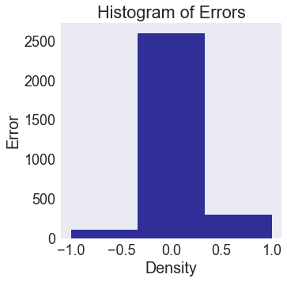

```python
%matplotlib inline
fig = plt.figure(figsize=(5,5))
ax1 = fig.add_subplot(1,1,1)

ax1.hist((t-y_hat), bins =3 , color='navy', alpha =0.8 , align = "mid" )
ax1.set(title='Histogram of Errors',
           ylabel='Error', xlabel = "Density")

ax1.grid()
plt.show()
```

```python
#see feature names
vectorizer.get_feature_names()
```

```
['08000839402 call2optout',
 '1000 cash',
 '150p msg',
 '2000 prize',
 '2003 account',
 '2003 account statement',
 '2lands row',
 '2nd attempt',
 '800 redeemed',
 '800 redeemed points',
 'account statement',
 'attempt contact',
 'caller prize',
 'chance win',
 'claim ur',
 'come home',
 'customer service',
 'decimal gt',
 'don know',
 'dont know',
 'double mins',
 'free entry',
 'good morning',
 'good night',
 'great day',
 'gt minutes',
 'half price',
 'happy birthday',
 'happy new',
 'happy new year',
 'http www',
 'identifier code',
 'joy father',
 'just got',
 'land line',
 'land line claim',
 'let know',
 'like lt',
 'like lt gt',
 'line claim',
```

[output cut: 25 more lines]

```
 'sorry ll',
 'sorry ll later',
 'suite342 2lands',
 'suite342 2lands row',
 'thats cool',
 'trying contact',
 'ts cs',
 'txt stop',
 'txt word',
 'ur cash',
 'urgent mobile',
 'valid 12hrs',
 've got',
 'watching tv',
 'won guaranteed']
```